# air_pollution_2022

### Background

Nepal's air quality in major cities is not always healthy. I did not always look at this from the data perspective, but being aware of it has really driven my desire to do so. For the purposes of this exploration, I will not focus on the sources, but just look at what data is available, and what is the quality of publicly available data.

The dataset here is from the Government of Nepal itself containing daily values from different stations. I greatly appreciate the open data sharing policy adopted by the Department of Environment which allows all concerned to take the data and understand it for ourselves. Let's begin.

```python
%matplotlib inline
import numpy as np
import pandas as pd
import matplotlib.pyplot as plt
import calendar
import seaborn as sns

# change the default runtime configurations
plt.rc('axes',linewidth=2,titlesize=20,labelsize=16,labelpad=5)
plt.rc('xtick',labelsize=12,top=False)
plt.rc('ytick',labelsize=12,right=False)
plt.rc('legend',fontsize='medium',framealpha=0.6,markerscale=2)
plt.rc('font',family='Arial')
plt.rc('mathtext',fontset='stix',default='it')
plt.rcParams['font.family'] = 'Sans Serif'
plt.rcParams['mathtext.fontset']='stix'

# Set a nice style
sns.set_style("darkgrid")
```

### Load the dataset, clean it up

```python
station_loc = 'Khumaltar'
data = pd.read_excel('daily-average-data-2022-all-stations-1714923065.xlsx',sheet_name=station_loc)
```

```python
data.info()
```

```
<class 'pandas.core.frame.DataFrame'>
RangeIndex: 292 entries, 0 to 291
Data columns (total 3 columns):
 #   Column  Non-Null Count  Dtype
---  ------  --------------  -----
 0   date    292 non-null    object
 1   PM2.5   243 non-null    float64
 2   PM10    254 non-null    float64
dtypes: float64(2), object(1)
memory usage: 7.0+ KB
```

```python
# Count nulls in each column
print("Missing values per column:")
print(data.isnull().sum())
```

```
Missing values per column:
date      0
PM2.5    49
PM10     38
dtype: int64
```

```python
# Check if any value is missing in the entire DataFrame
print("\nAny missing values in the DataFrame?")
print(data.isnull().values.any())
```

```
Any missing values in the DataFrame?
True
```

```python
data.head()
```

|  | date | PM2.5 | PM10 |
| --- | --- | --- | --- |
| 0 | 2022-03-15 | NaN | NaN |
| 1 | 2022-03-16 | NaN | NaN |
| 2 | 2022-03-17 | NaN | NaN |
| 3 | 2022-03-18 | NaN | NaN |
| 4 | 2022-03-19 | NaN | NaN |

```python
df_ = data.dropna()
df_.head()
```

|  | date | PM2.5 | PM10 |
| --- | --- | --- | --- |
| 7 | 2022-03-22 | 70.764399 | 183.014240 |
| 8 | 2022-03-23 | 79.836837 | 207.656542 |
| 9 | 2022-03-24 | 71.542840 | 170.480046 |
| 10 | 2022-03-25 | 56.742322 | 164.989258 |
| 11 | 2022-03-26 | 65.004515 | 227.428175 |

After dropping the null rows, we see that almost three months of data is missing for this year, January, February and almost all of March. This is not great and reinforces the need for better operation of these stations.

```python
df = df_.copy()
```

```python
df.info()
```

```
<class 'pandas.core.frame.DataFrame'>
Index: 243 entries, 7 to 291
Data columns (total 3 columns):
 #   Column  Non-Null Count  Dtype
---  ------  --------------  -----
 0   date    243 non-null    object
 1   PM2.5   243 non-null    float64
 2   PM10    243 non-null    float64
dtypes: float64(2), object(1)
memory usage: 7.6+ KB
```

```python
print(f'Data available for only {243/365:.0%} of the days!')
```

```
Data available for only 67% of the days!
```

```python
df.describe()
```

|  | PM2.5 | PM10 |
| --- | --- | --- |
| count | 243.000000 | 243.000000 |
| mean | 38.497039 | 76.511941 |
| std | 24.170061 | 56.516417 |
| min | 5.632493 | 7.931645 |
| 25% | 16.159485 | 31.162742 |
| 50% | 37.305813 | 69.504583 |
| 75% | 55.151019 | 100.875036 |
| max | 113.766135 | 288.759236 |

```python
df['date'] = pd.to_datetime(df['date'])
```

```python
df.head()
```

|  | date | PM2.5 | PM10 |
| --- | --- | --- | --- |
| 7 | 2022-03-22 | 70.764399 | 183.014240 |
| 8 | 2022-03-23 | 79.836837 | 207.656542 |
| 9 | 2022-03-24 | 71.542840 | 170.480046 |
| 10 | 2022-03-25 | 56.742322 | 164.989258 |
| 11 | 2022-03-26 | 65.004515 | 227.428175 |

Let's add month columns to generate some month-by-month comparisons

```python
df['month'] = df['date'].dt.month
# Add month name (full name)
df['month_name'] = df['date'].dt.month_name()
```

```python
df
```

|  | date | PM2.5 | PM10 | month | month_name |
| --- | --- | --- | --- | --- | --- |
| 7 | 2022-03-22 | 70.764399 | 183.014240 | 3 | March |
| 8 | 2022-03-23 | 79.836837 | 207.656542 | 3 | March |
| 9 | 2022-03-24 | 71.542840 | 170.480046 | 3 | March |
| 10 | 2022-03-25 | 56.742322 | 164.989258 | 3 | March |
| 11 | 2022-03-26 | 65.004515 | 227.428175 | 3 | March |
| ... | ... | ... | ... | ... | ... |
| 287 | 2022-12-27 | 68.250050 | 132.689057 | 12 | December |
| 288 | 2022-12-28 | 72.859415 | 113.842732 | 12 | December |
| 289 | 2022-12-29 | 95.317373 | 138.543311 | 12 | December |
| 290 | 2022-12-30 | 113.766135 | 173.345975 | 12 | December |
| 291 | 2022-12-31 | 85.316455 | 126.990361 | 12 | December |

243 rows × 5 columns

```python
df.isnull().sum()
```

```
date          0
PM2.5         0
PM10          0
month         0
month_name    0
dtype: int64
```

```python
df.isna().sum()
```

```
date          0
PM2.5         0
PM10          0
month         0
month_name    0
dtype: int64
```

## Analysis and plots

We'll focus only on the PM$_{2.5}$ levels here

```python
# what is the annual average
yearly_stats = df['PM2.5'].agg(['mean', 'max', 'min', 'std'])
print(yearly_stats)
```

```
mean     38.497039
max     113.766135
min       5.632493
std      24.170061
Name: PM2.5, dtype: float64
```

Yearly average is only $3 ~\mu g / m^3$ above the Interim Target I.

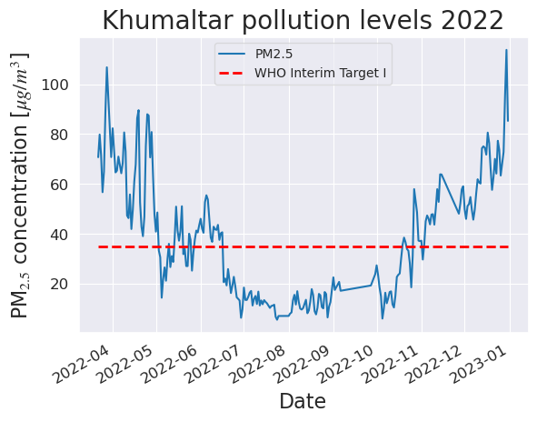

```python
# plot the pollution levels
fig, ax = plt.subplots()
df.plot(y='PM2.5',x='date',ax=ax)
# add in the WHO Interim Target I line
ax.hlines(35,df['date'].min(),df['date'].max(),lw=2.0,color='r', linestyle='--',label='WHO Interim Target I')
ax.set_title(f'{station_loc} pollution levels 2022')
ax.set_ylabel(r'PM$_{2.5}$ concentration [$\mu g / m^3$]')
ax.set_xlabel('Date')
ax.legend()
plt.show()
```

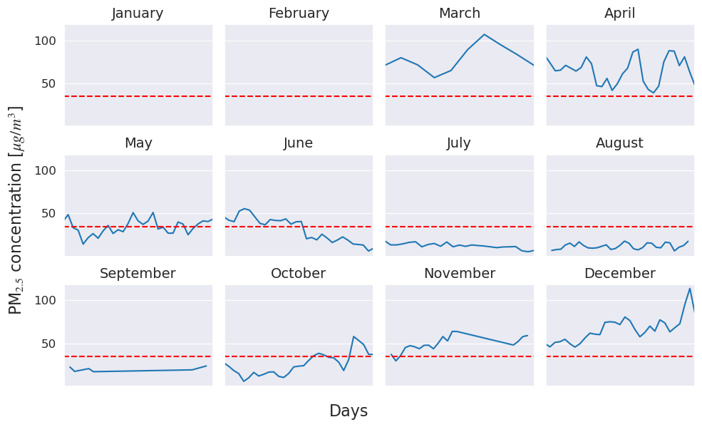

```python
# let's look at how the PM2.5 levels fluctuated every month in Khumaltar
fig_monthly_plt, axes = plt.subplots(3, 4, sharey=True, figsize=(10, 6))
axes = axes.flatten()

for month in range(1, 13):
    # select the months and plot them
    month_data = df[df['date'].dt.month == month]
    month_data.plot(x='date', y='PM2.5', ax=axes[month-1], legend=False)
    axes[month-1].set_title(calendar.month_name[month],fontsize=14)
    axes[month-1].axhline(y=35, color='r', linestyle='--')
    axes[month-1].get_xaxis().set_visible(False)  # Hide entire x-axis

fig_monthly_plt.supylabel(r'PM$_{2.5}$ concentration [$\mu g / m^3$]',fontsize=16)
fig_monthly_plt.supxlabel('Days',fontsize=16)
plt.tight_layout()
plt.show()
```

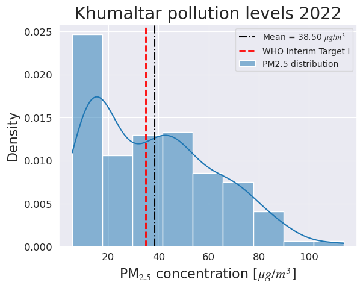

```python
# histogram with KDE overlay
fig_dist, ax = plt.subplots()
sns.histplot(data=df['PM2.5'], stat='density', kde=True, label='PM2.5 distribution', ax=ax)
ax.axvline(df['PM2.5'].mean(),color='k',linestyle='-.',label=rf'Mean = {df['PM2.5'].mean():.2f} $\mu g / m^3$')
ax.axvline(35,lw=2.0,color='r', linestyle='--',label='WHO Interim Target I')
ax.set_title(f'{station_loc} pollution levels 2022')
ax.set_xlabel(r'PM$_{2.5}$ concentration [$\mu g / m^3$]')
ax.legend()
plt.show()
```

You can visualize both the histogram and the KDE at once or turn off the `kde=True` and look at separate KDE plot as shown below. Multiple KDEs make comparisons easier than with histograms.

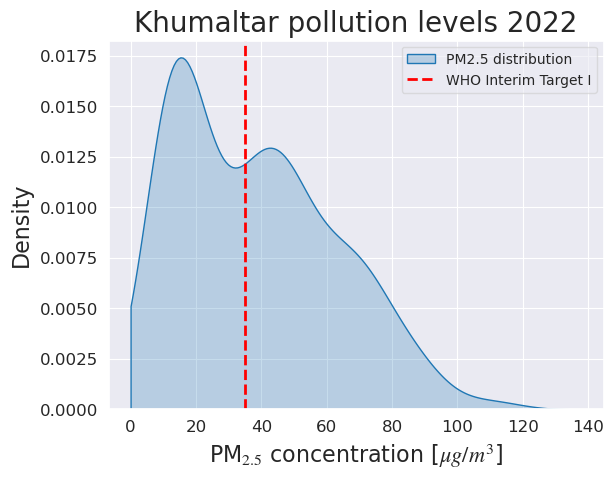

```python
# smooth histogram
fig_dist, ax = plt.subplots()
sns.kdeplot(data=df['PM2.5'],clip=(0, None),fill=True,ax=ax,label='PM2.5 distribution')
ax.axvline(35,lw=2.0,color='r', linestyle='--',label='WHO Interim Target I')
ax.set_title(f'{station_loc} pollution levels 2022')
ax.set_xlabel(r'PM$_{2.5}$ concentration [$\mu g / m^3$]')
ax.legend()
plt.show()
```

In most of the days, PM$_{2.5}$ concentration is above the Interim Target I threshold value.

```python
# Group by month and calculate statistics
monthly_stats = df.groupby('month')['PM2.5'].agg(['mean', 'max', 'min', 'std'])
monthly_stats
```

| month | mean | max | min | std |
| --- | --- | --- | --- | --- |
| 3 | 78.840317 | 106.785903 | 56.742322 | 14.976586 |
| 4 | 65.079130 | 89.605176 | 39.122431 | 15.180899 |
| 5 | 34.520894 | 51.116013 | 14.452331 | 8.692586 |
| 6 | 31.545420 | 55.507292 | 6.417772 | 14.411653 |
| 7 | 12.557889 | 18.532033 | 5.632493 | 3.122841 |
| 8 | 12.082870 | 17.919984 | 6.569223 | 3.418842 |
| 9 | 20.247806 | 23.882044 | 17.241700 | 2.688924 |
| 10 | 26.028333 | 57.978042 | 6.095956 | 13.068853 |
| 11 | 48.996168 | 63.908758 | 29.752348 | 9.109985 |
| 12 | 66.508628 | 113.766135 | 45.739315 | 15.003513 |

In July, August and September, pollution levels are quite low and stay that way with low fluctuations. We'll visualize this later.

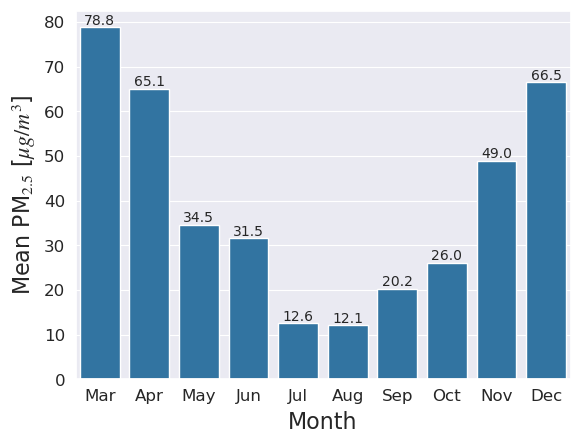

```python
# get the monthly means
fig_monthly_means, ax = plt.subplots()

sns.barplot(x='month', y='mean', data=monthly_stats, ax=ax)
ax.set_ylabel(r'Mean PM$_{2.5}$ [$\mu g / m^3$]')
ax.set_xlabel('Month')
ax.bar_label(ax.containers[0], fmt='%.1f', fontsize=10)

# work with current axis
ax = plt.gca()
# Get current tick positions where we will put the abbreviated months as labels
tick_positions = ax.get_xticks()
# Create month labels for the actual months in the data. No Jan or Feb
labels = [calendar.month_abbr[i] for i in range(3, 13)]
# Set ticks first, then labels
ax.set_xticks(tick_positions)
ax.set_xticklabels(labels)

plt.show()
```

### Monthly distributions

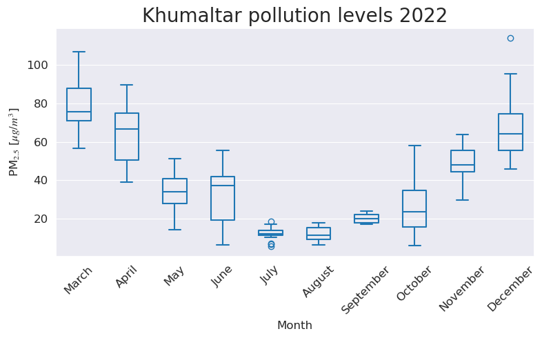

```python
# Create a simple boxplot using seaborn
fig_bxplt, ax=plt.subplots(figsize=(8, 5))
sns.boxplot(data=df, x='month_name', y='PM2.5', ax=ax, width=0.5,fill = False, gap=0.01)
# ax.axhline(y=35, color='r', linestyle='--', linewidth=2, label='WHO Interim Target I')
ax.set_title(f'{station_loc} pollution levels 2022')
ax.set_xlabel('Month', fontsize=12)
ax.set_ylabel(r'PM$_{2.5}$ [$\mu g / m^3$]', fontsize=12)
plt.xticks(rotation=45)
# ax.legend()
plt.tight_layout()
plt.show()
```

The boxplot above looks clean and pretty good, but I wanted to see if this can be improved. Below, the boxes are colored by the median PM$_{2.5}$ concentration for the month.

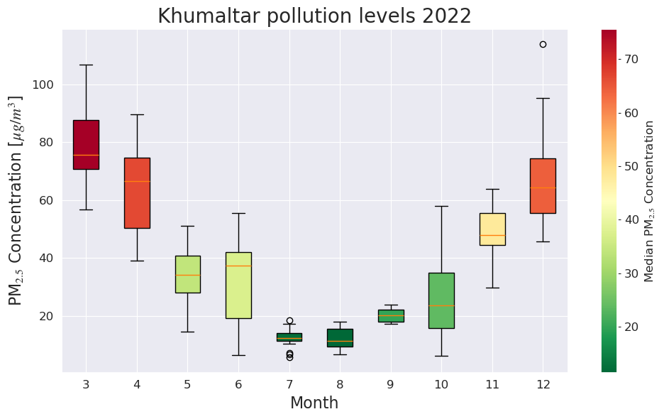

```python
# Calculate median for each month for coloring
monthly_median = df.groupby('month')['PM2.5'].median()

# Create colormap
cmap = plt.cm.RdYlGn_r  # red=high pollution
norm = plt.Normalize(vmin=monthly_median.min(), vmax=monthly_median.max())
colors = [cmap(norm(value)) for value in monthly_median]

# Plot
fig, ax = plt.subplots(figsize=(10, 6))
bp = ax.boxplot([df[df['month'] == m]['PM2.5'] for m in range(3, 13)],
                 patch_artist=True,
                 tick_labels=range(3, 13))
# ax.axhline(y=35, color='k', linestyle='--', linewidth=2, alpha=0.5, label='WHO Interim Target I')

# Color each box
for patch, color in zip(bp['boxes'], colors):
    patch.set_facecolor(color)

ax.set_title(f'{station_loc} pollution levels 2022')
ax.set_xlabel('Month')
ax.set_ylabel(r'PM$_{2.5}$ Concentration [$\mu g / m^3$]')

# Add colorbar
sm = plt.cm.ScalarMappable(cmap=cmap, norm=norm)
sm.set_array([])
cbar = plt.colorbar(sm, ax=ax)
cbar.set_label(r'Median PM$_{2.5}$ Concentration', fontsize=12)
# ax.legend()
plt.tight_layout()
plt.show()
```

Above, the boxplots are colored based on monthly median PM$_{2.5}$ levels.

There is no data from January and February, they are probably December/March like in their distribution.

Violin plots look nicer

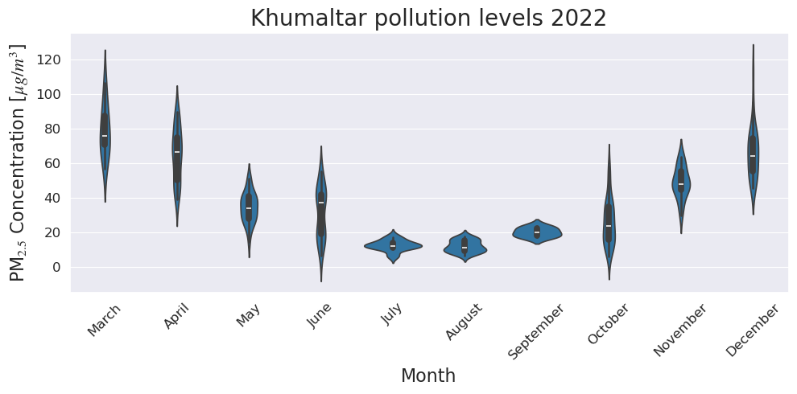

```python
fig, ax=plt.subplots(figsize=(10, 5))
sns.violinplot(data=df, ax=ax, x='month_name', y='PM2.5')
# ax.axhline(y=35, color='r', linestyle='--', linewidth=2, label='WHO Interim Target I')
ax.set_title(f'{station_loc} pollution levels 2022')
ax.set_xlabel('Month')
ax.set_ylabel(r'PM$_{2.5}$ Concentration [$\mu g / m^3$]')
plt.xticks(rotation=45)
# ax.legend()
plt.tight_layout()
plt.show()
```

### Lastly, let's take a look at what % of days each month was the $PM2.5$ level greater than the interim target value of $35 \mu g / m^3$

```python
monthly_counts = df.groupby('month_name').size()
print(monthly_counts)
```

```
month_name
April        30
August       30
December     31
July         25
June         30
March        10
May          31
November     19
October      31
September     6
dtype: int64
```

```python
monthly_counts = df.groupby('month').size()
print(monthly_counts)
```

```
month
3     10
4     30
5     31
6     30
7     25
8     30
9      6
10    31
11    19
12    31
dtype: int64
```

Above - Data was collected for that many days each month.

```python
high_values = df[df['PM2.5'] > 35]
high_pollution_days = high_values.groupby('month').size()
print(high_pollution_days)
```

```
month
3     10
4     30
5     15
6     16
10     8
11    18
12    31
dtype: int64
```

```python
# Count and calculate the percentage
# applying a function where the values greater than 35 are counted
monthly_stats_2 = df.groupby('month')['PM2.5'].agg([
    ('total', 'count'),
    ('above_35', lambda x: (x > 35).sum())
])
monthly_stats_2['percentage'] = (monthly_stats_2['above_35'] / monthly_stats_2['total'] * 100).round(1)
print(monthly_stats_2)
```

```
       total  above_35  percentage
month
3         10        10       100.0
4         30        30       100.0
5         31        15        48.4
6         30        16        53.3
7         25         0         0.0
8         30         0         0.0
9          6         0         0.0
10        31         8        25.8
11        19        18        94.7
12        31        31       100.0
```

Above - PM$_{2.5}$ concentration exceeded the Interim Target in these many days.

```python
# new dataframe
monthly_stats_2
```

| month | total | above_35 | percentage |
| --- | --- | --- | --- |
| 3 | 10 | 10 | 100.0 |
| 4 | 30 | 30 | 100.0 |
| 5 | 31 | 15 | 48.4 |
| 6 | 30 | 16 | 53.3 |
| 7 | 25 | 0 | 0.0 |
| 8 | 30 | 0 | 0.0 |
| 9 | 6 | 0 | 0.0 |
| 10 | 31 | 8 | 25.8 |
| 11 | 19 | 18 | 94.7 |
| 12 | 31 | 31 | 100.0 |

```python
# another way of filtering the high pollution days
high_values = df[df['PM2.5'] > 35]
high_pollution = high_values.groupby('month').size()
print(high_pollution)
```

```
month
3     10
4     30
5     15
6     16
10     8
11    18
12    31
dtype: int64
```

```python
total_days = df.groupby('month')['PM2.5'].size()
print(total_days)
```

```
month
3     10
4     30
5     31
6     30
7     25
8     30
9      6
10    31
11    19
12    31
Name: PM2.5, dtype: int64
```

```python
percentage = ((high_pollution / total_days) * 100).round(1)
print(percentage)
```

```
month
3     100.0
4     100.0
5      48.4
6      53.3
7       NaN
8       NaN
9       NaN
10     25.8
11     94.7
12    100.0
dtype: float64
```

## Summary

**From November to April in almost 100 % of the days, pollution levels at Khumaltar station did not meet the WHO Interim Target I.**

**From May to October, the situation improves quite well - potentially helped by monsoon.**

**This analysis was for Khumaltar, but it could be repeated for any of the stations in the major cities.**

**The stations responsible for data collection should do better to get this data for all the days of the year.**

**Finally, plots here can be compared with Figures 70, 72, 73 and 74 of the 2022 report published by the Department of Environment, Nepal.**